# Project: Investigate a Dataset - [tmdb-movies dataset]

- Introduction
- Data Wrangling
- Exploratory Data Analysis
- Conclusions

## Introduction

### Dataset Description

> I analyzed the movies dataset and communicated my findings about it. I used the Python libraries such as NumPy, pandas, and Matplotlib to make my analysis easier.

> This data set contains information about over 10,000 movies collected from The Movie Database (TMDb), including user ratings and revenue for the movies. Certain columns, like ‘cast’ and ‘genres’, contain multiple values separated by pipe (|) characters. The final two columns ending with “_adj” show the budget and revenue of the associated movie in terms of 2010 dollars, accounting for inflation over time. I will be dropping some of these columsn later as I do not need them all for my analysis.

### Description of the raw dataset columns:-

- **id** - A unique identifier for each movie.
- **popularity** - A numeric quantity specifying the movie popularity.
- **budget** - The budget in which the movie was made.
- **revenue** - The worldwide revenue generated by the movie.
- **original_title** - The title of the movie before translation or adaptation.
- **cast** - The name of lead and supporting actors.
- **homepage** - A link to the homepage of the movie.
- **director** - Movie Director
- **tagline** - Movie's tagline.
- **overview** - A brief description of the movie.
- **runtime** - The running time of the movie in minutes.
- **genre** - The genre of the movie, Action, Comedy ,Thriller etc.
- **production_companies** - The production house of the movie.
- **release_date** - The date on which it was released.
- **vote_count** - the count of votes recieved.
- **vote_average** - average ratings the movie recieved.
- **release_year** - Movie release year
- **budget_adj** - show the budget of the associated movie in terms of 2010 dollars, accounting for
- **revenue_adj** - show the revenue of the associated movie in terms of 2010 dollars, accounting for

### Questions for Analysis:

> **1**: What are the number of movies released each year?

> **2**: Waht is the relationship between movie budget and revenue?

> **3**: What is the most profitable movie?

> **4**: What is the least profitable movie?

```python
# Use this cell to set up import statements for all of the packages that you
#   plan to use.
import pandas as pd
import numpy as np
import matplotlib.pyplot as plt
import seaborn as sns

# Remember to include a 'magic word' so that your visualizations are plotted
#   inline with the notebook. See this page for more:
#   http://ipython.readthedocs.io/en/stable/interactive/magics.html
%matplotlib inline
```

```python
# Upgrade pandas to use dataframe.explode() function.
!pip install --upgrade pandas==0.25.0
```

## Data Wrangling

> **Tip**: In this section of the report, you will load in the data, check for cleanliness, and then trim and clean your dataset for analysis. Make sure that you **document your data cleaning steps in mark-down cells precisely and justify your cleaning decisions.**

### General Properties

> **Tip**: You should *not* perform too many operations in each cell. Create cells freely to explore your data. One option that you can take with this project is to do a lot of explorations in an initial notebook. These don't have to be organized, but make sure you use enough comments to understand the purpose of each code cell. Then, after you're done with your analysis, create a duplicate notebook where you will trim the excess and organize your steps so that you have a flowing, cohesive report.

```python
# Load your data and print out a few lines. Perform operations to inspect data
#   types and look for instances of missing or possibly errant data.
movies = pd.read_csv('tmdb-movies.csv')
movies.head()
```

|  | id | imdb_id | popularity | budget | revenue | original_title | cast | homepage | director | tagline | ... | overview | runtime | genres | production_companies | release_date | vote_count | vote_average | release_year | budget_adj | revenue_adj |
| --- | --- | --- | --- | --- | --- | --- | --- | --- | --- | --- | --- | --- | --- | --- | --- | --- | --- | --- | --- | --- | --- |
| 0 | 135397 | tt0369610 | 32.985763 | 150000000 | 1513528810 | Jurassic World | Chris Pratt\|Bryce Dallas Howard\|Irrfan Khan\|Vi... | http://www.jurassicworld.com/ | Colin Trevorrow | The park is open. | ... | Twenty-two years after the events of Jurassic ... | 124 | Action\|Adventure\|Science Fiction\|Thriller | Universal Studios\|Amblin Entertainment\|Legenda... | 6/9/15 | 5562 | 6.5 | 2015 | 1.379999e+08 | 1.392446e+09 |
| 1 | 76341 | tt1392190 | 28.419936 | 150000000 | 378436354 | Mad Max: Fury Road | Tom Hardy\|Charlize Theron\|Hugh Keays-Byrne\|Nic... | http://www.madmaxmovie.com/ | George Miller | What a Lovely Day. | ... | An apocalyptic story set in the furthest reach... | 120 | Action\|Adventure\|Science Fiction\|Thriller | Village Roadshow Pictures\|Kennedy Miller Produ... | 5/13/15 | 6185 | 7.1 | 2015 | 1.379999e+08 | 3.481613e+08 |
| 2 | 262500 | tt2908446 | 13.112507 | 110000000 | 295238201 | Insurgent | Shailene Woodley\|Theo James\|Kate Winslet\|Ansel... | http://www.thedivergentseries.movie/#insurgent | Robert Schwentke | One Choice Can Destroy You | ... | Beatrice Prior must confront her inner demons ... | 119 | Adventure\|Science Fiction\|Thriller | Summit Entertainment\|Mandeville Films\|Red Wago... | 3/18/15 | 2480 | 6.3 | 2015 | 1.012000e+08 | 2.716190e+08 |
| 3 | 140607 | tt2488496 | 11.173104 | 200000000 | 2068178225 | Star Wars: The Force Awakens | Harrison Ford\|Mark Hamill\|Carrie Fisher\|Adam D... | http://www.starwars.com/films/star-wars-episod... | J.J. Abrams | Every generation has a story. | ... | Thirty years after defeating the Galactic Empi... | 136 | Action\|Adventure\|Science Fiction\|Fantasy | Lucasfilm\|Truenorth Productions\|Bad Robot | 12/15/15 | 5292 | 7.5 | 2015 | 1.839999e+08 | 1.902723e+09 |
| 4 | 168259 | tt2820852 | 9.335014 | 190000000 | 1506249360 | Furious 7 | Vin Diesel\|Paul Walker\|Jason Statham\|Michelle ... | http://www.furious7.com/ | James Wan | Vengeance Hits Home | ... | Deckard Shaw seeks revenge against Dominic Tor... | 137 | Action\|Crime\|Thriller | Universal Pictures\|Original Film\|Media Rights ... | 4/1/15 | 2947 | 7.3 | 2015 | 1.747999e+08 | 1.385749e+09 |

5 rows × 21 columns

**Check the number of rows and columns (shape of the dataset)**

```python
movies.shape
```

```
(10866, 21)
```

- From above output, there are **10866 rows** and **21 columns**

**Check all columns**

```python
movies.columns
```

```
Index(['id', 'imdb_id', 'popularity', 'budget', 'revenue', 'original_title',
       'cast', 'homepage', 'director', 'tagline', 'keywords', 'overview',
       'runtime', 'genres', 'production_companies', 'release_date',
       'vote_count', 'vote_average', 'release_year', 'budget_adj',
       'revenue_adj'],
      dtype='object')
```

**Check datatype of each variable**

```python
movies.dtypes
```

```
id                        int64
imdb_id                  object
popularity              float64
budget                    int64
revenue                   int64
original_title           object
cast                     object
homepage                 object
director                 object
tagline                  object
keywords                 object
overview                 object
runtime                   int64
genres                   object
production_companies     object
release_date             object
vote_count                int64
vote_average            float64
release_year              int64
budget_adj              float64
revenue_adj             float64
dtype: object
```

- From above output, **release_date** variable is in string and it should be in the **datetime** form/dtype

**Check for duplicates in the data set**

```python
sum(movies.duplicated())
```

```
1
```

- From above output, there is **1** duplicate in the dataset

```python
# check for unique values in each variable in the dataset
movies.nunique()
```

```
id                      10865
imdb_id                 10855
popularity              10814
budget                    557
revenue                  4702
original_title          10571
cast                    10719
homepage                 2896
director                 5067
tagline                  7997
keywords                 8804
overview                10847
runtime                   247
genres                   2039
production_companies     7445
release_date             5909
vote_count               1289
vote_average               72
release_year               56
budget_adj               2614
revenue_adj              4840
dtype: int64
```

```python
# check detailed info in the dataset - to also display missing values in each column
movies.info()
```

```
<class 'pandas.core.frame.DataFrame'>
RangeIndex: 10866 entries, 0 to 10865
Data columns (total 21 columns):
id                      10866 non-null int64
imdb_id                 10856 non-null object
popularity              10866 non-null float64
budget                  10866 non-null int64
revenue                 10866 non-null int64
original_title          10866 non-null object
cast                    10790 non-null object
homepage                2936 non-null object
director                10822 non-null object
tagline                 8042 non-null object
keywords                9373 non-null object
overview                10862 non-null object
runtime                 10866 non-null int64
genres                  10843 non-null object
production_companies    9836 non-null object
release_date            10866 non-null object
vote_count              10866 non-null int64
vote_average            10866 non-null float64
release_year            10866 non-null int64
budget_adj              10866 non-null float64
revenue_adj             10866 non-null float64
dtypes: float64(4), int64(6), object(11)
memory usage: 1.7+ MB
```

**I can see null values present in the following variables**:

*imbd-id*, *cast*, *homepage*, *director*, *tagline*, *keywords*, *overview*, *genres*, and *production-companies*

**I can see all & different datatypes for each column as well as columns which will not be used**

```python
# check null counts in each variable in the dataset
movies.isnull().sum()
```

```
id                         0
imdb_id                   10
popularity                 0
budget                     0
revenue                    0
original_title             0
cast                      76
homepage                7930
director                  44
tagline                 2824
keywords                1493
overview                   4
runtime                    0
genres                    23
production_companies    1030
release_date               0
vote_count                 0
vote_average               0
release_year               0
budget_adj                 0
revenue_adj                0
dtype: int64
```

```python
# Descriptive statistics summary
movies.describe()
```

|  | id | popularity | budget | revenue | runtime | vote_count | vote_average | release_year | budget_adj | revenue_adj |
| --- | --- | --- | --- | --- | --- | --- | --- | --- | --- | --- |
| count | 10866.000000 | 10866.000000 | 1.086600e+04 | 1.086600e+04 | 10866.000000 | 10866.000000 | 10866.000000 | 10866.000000 | 1.086600e+04 | 1.086600e+04 |
| mean | 66064.177434 | 0.646441 | 1.462570e+07 | 3.982332e+07 | 102.070863 | 217.389748 | 5.974922 | 2001.322658 | 1.755104e+07 | 5.136436e+07 |
| std | 92130.136561 | 1.000185 | 3.091321e+07 | 1.170035e+08 | 31.381405 | 575.619058 | 0.935142 | 12.812941 | 3.430616e+07 | 1.446325e+08 |
| min | 5.000000 | 0.000065 | 0.000000e+00 | 0.000000e+00 | 0.000000 | 10.000000 | 1.500000 | 1960.000000 | 0.000000e+00 | 0.000000e+00 |
| 25% | 10596.250000 | 0.207583 | 0.000000e+00 | 0.000000e+00 | 90.000000 | 17.000000 | 5.400000 | 1995.000000 | 0.000000e+00 | 0.000000e+00 |
| 50% | 20669.000000 | 0.383856 | 0.000000e+00 | 0.000000e+00 | 99.000000 | 38.000000 | 6.000000 | 2006.000000 | 0.000000e+00 | 0.000000e+00 |
| 75% | 75610.000000 | 0.713817 | 1.500000e+07 | 2.400000e+07 | 111.000000 | 145.750000 | 6.600000 | 2011.000000 | 2.085325e+07 | 3.369710e+07 |
| max | 417859.000000 | 32.985763 | 4.250000e+08 | 2.781506e+09 | 900.000000 | 9767.000000 | 9.200000 | 2015.000000 | 4.250000e+08 | 2.827124e+09 |

### Data Cleaning

> **Tip**: Make sure that you keep your reader informed on the steps that you are taking in your investigation. Follow every code cell, or every set of related code cells, with a markdown cell to describe to the reader what was found in the preceding cell(s). Try to make it so that the reader can then understand what they will be seeing in the following cell(s).

> After discussing the structure of the data and any problems that need to be cleaned, perform those cleaning steps in the second part of this section.

> I will clean up the data to make it easy to handle, such as:
> 1. Drop columns that are not needed
> 2. Drop the duplicate values
> 3. Replacing zero values with null values then with the mean of the column
> 4. Changing the format of release_date from string to datetime format

### 1. Drop columns that are not needed

- Also set inplace as True so I can keep the changes and go on to clean other columns.

```python
# this function will drop columns using the list of column names
movies.drop(['homepage','overview','keywords', 'imdb_id', 'production_companies','cast', 'director', 'tagline',], axis=1, inplace=True)
movies.columns
```

```
Index(['id', 'popularity', 'budget', 'revenue', 'original_title', 'runtime',
       'genres', 'release_date', 'vote_count', 'vote_average', 'release_year',
       'budget_adj', 'revenue_adj'],
      dtype='object')
```

**Above output is the new columns in the dataset after dropping unwanted columns**

```python
movies.info()
```

```
<class 'pandas.core.frame.DataFrame'>
RangeIndex: 10866 entries, 0 to 10865
Data columns (total 13 columns):
id                10866 non-null int64
popularity        10866 non-null float64
budget            10866 non-null int64
revenue           10866 non-null int64
original_title    10866 non-null object
runtime           10866 non-null int64
genres            10843 non-null object
release_date      10866 non-null object
vote_count        10866 non-null int64
vote_average      10866 non-null float64
release_year      10866 non-null int64
budget_adj        10866 non-null float64
revenue_adj       10866 non-null float64
dtypes: float64(4), int64(6), object(3)
memory usage: 1.1+ MB
```

**This shows a better dataset with the genre column still having missing values**

### 2. Drop Duplicates

```python
# drop duplicates
movies.drop_duplicates(inplace=True)
```

```python
# print number of duplicates to confirm that the duplicates have been dropped
movies.duplicated().sum()
```

```
0
```

### 3. Check the columns with zero values (columns with int and float dtypes), count them and replace with mean

```python
#counting zero values in the budget column.
movies_budget_count =  movies.groupby('budget').count()['id']
movies_budget_count.head()
```

```
budget
0    5696
1       4
2       1
3       3
5       1
Name: id, dtype: int64
```

```python
#counting zero values in the revenue column.
movies_revenue_count =  movies.groupby('revenue').count()['id']
movies_revenue_count.head()
```

```
revenue
0    6016
2       2
3       3
5       2
6       2
Name: id, dtype: int64
```

```python
#counting zero values in the revenue_adj column.
movies_revenue_adj_count =  movies.groupby('revenue_adj').count()['id']
movies_revenue_adj_count.head()
```

```
revenue_adj
0.000000    6016
2.370705       1
2.861934       1
3.038360       1
5.926763       1
Name: id, dtype: int64
```

```python
#counting zero values in the budget_adj column.
movies_budget_adj_count =  movies.groupby('budget_adj').count()['id']
movies_budget_adj_count.head()
```

```
budget_adj
0.000000    5696
0.921091       1
0.969398       1
1.012787       1
1.309053       1
Name: id, dtype: int64
```

```python
#counting zero values in the runtime column.
movies_runtime_count =  movies.groupby('runtime').count()['id']
movies_runtime_count.head()
```

```
runtime
0    31
2     5
3    11
4    17
5    17
Name: id, dtype: int64
```

- **The 5 above outputs shows a lot of zero values in each column**

**Here I will go on to replace all the zero values in the columns with null values**

```python
movies['budget'] = movies['budget'].replace(0, np.NaN)
movies['revenue'] = movies['revenue'].replace(0, np.NaN)
movies['budget_adj'] = movies['budget_adj'].replace(0, np.NaN)
movies['revenue_adj'] = movies['revenue_adj'].replace(0, np.NaN)
movies['runtime'] = movies['runtime'].replace(0, np.NAN)
```

```python
# see if nulls are added in budget and revenue columns
movies.info()
```

```
<class 'pandas.core.frame.DataFrame'>
Int64Index: 10865 entries, 0 to 10865
Data columns (total 13 columns):
id                10865 non-null int64
popularity        10865 non-null float64
budget            5169 non-null float64
revenue           4849 non-null float64
original_title    10865 non-null object
runtime           10834 non-null float64
genres            10842 non-null object
release_date      10865 non-null object
vote_count        10865 non-null int64
vote_average      10865 non-null float64
release_year      10865 non-null int64
budget_adj        5169 non-null float64
revenue_adj       4849 non-null float64
dtypes: float64(7), int64(3), object(3)
memory usage: 1.2+ MB
```

**I would replace the zero values with the mean of each column**

```python
movies.fillna(movies.mean(), inplace=True);
```

```python
movies.info()
```

```
<class 'pandas.core.frame.DataFrame'>
Int64Index: 10865 entries, 0 to 10865
Data columns (total 13 columns):
id                10865 non-null int64
popularity        10865 non-null float64
budget            10865 non-null float64
revenue           10865 non-null float64
original_title    10865 non-null object
runtime           10865 non-null float64
genres            10842 non-null object
release_date      10865 non-null object
vote_count        10865 non-null int64
vote_average      10865 non-null float64
release_year      10865 non-null int64
budget_adj        10865 non-null float64
revenue_adj       10865 non-null float64
dtypes: float64(7), int64(3), object(3)
memory usage: 1.2+ MB
```

**All columns with null values have been filled with mean and the genre column didn't change because it is a string object**

**Now check the descriptive summary of the dataset**

```python
movies.describe()
```

|  | id | popularity | budget | revenue | runtime | vote_count | vote_average | release_year | budget_adj | revenue_adj |
| --- | --- | --- | --- | --- | --- | --- | --- | --- | --- | --- |
| count | 10865.000000 | 10865.000000 | 1.086500e+04 | 1.086500e+04 | 10865.000000 | 10865.000000 | 10865.000000 | 10865.000000 | 1.086500e+04 | 1.086500e+04 |
| mean | 66066.374413 | 0.646446 | 3.073958e+07 | 8.923886e+07 | 102.363855 | 217.399632 | 5.975012 | 2001.321859 | 3.688907e+07 | 1.151009e+08 |
| std | 92134.091971 | 1.000231 | 2.683275e+07 | 1.082720e+08 | 30.904039 | 575.644627 | 0.935138 | 12.813260 | 2.894088e+07 | 1.328386e+08 |
| min | 5.000000 | 0.000065 | 1.000000e+00 | 2.000000e+00 | 2.000000 | 10.000000 | 1.500000 | 1960.000000 | 9.210911e-01 | 2.370705e+00 |
| 25% | 10596.000000 | 0.207575 | 1.925000e+07 | 4.109806e+07 | 90.000000 | 17.000000 | 5.400000 | 1995.000000 | 2.460594e+07 | 5.878518e+07 |
| 50% | 20662.000000 | 0.383831 | 3.073958e+07 | 8.923886e+07 | 99.000000 | 38.000000 | 6.000000 | 2006.000000 | 3.688907e+07 | 1.151009e+08 |
| 75% | 75612.000000 | 0.713857 | 3.073958e+07 | 8.923886e+07 | 111.000000 | 146.000000 | 6.600000 | 2011.000000 | 3.688907e+07 | 1.151009e+08 |
| max | 417859.000000 | 32.985763 | 4.250000e+08 | 2.781506e+09 | 900.000000 | 9767.000000 | 9.200000 | 2015.000000 | 4.250000e+08 | 2.827124e+09 |

### 4. Change data type of "release_date" from string to datetime

```python
movies['release_date'] = pd.to_datetime(movies['release_date'])
```

**Now check the data type of release_date column**

```python
movies.dtypes
movies['release_date'].head()
```

```
0   2015-06-09
1   2015-05-13
2   2015-03-18
3   2015-12-15
4   2015-04-01
Name: release_date, dtype: datetime64[ns]
```

## Exploratory Data Analysis

> **Tip**: Now that you've trimmed and cleaned your data, you're ready to move on to exploration. **Compute statistics** and **create visualizations** with the goal of addressing the research questions that you posed in the Introduction section. You should compute the relevant statistics throughout the analysis when an inference is made about the data. Note that at least two or more kinds of plots should be created as part of the exploration, and you must compare and show trends in the varied visualizations.

> **Tip**: - Investigate the stated question(s) from multiple angles. It is recommended that you be systematic with your approach. Look at one variable at a time, and then follow it up by looking at relationships between variables. You should explore at least three variables in relation to the primary question. This can be an exploratory relationship between three variables of interest, or looking at how two independent variables relate to a single dependent variable of interest. Lastly, you should perform both single-variable (1d) and multiple-variable (2d) explorations.

#### Checking what the data looks like by using a Histogram

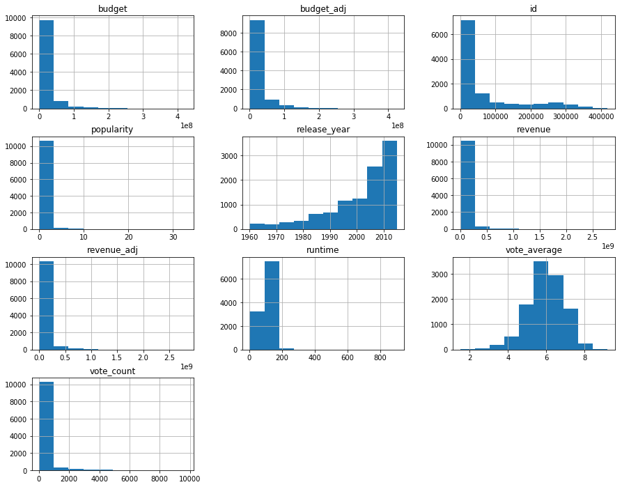

```python
movies.hist(figsize=(15,12));
```

**Observations**

1. Most movies lie in the budget range 0 to 0.5 on an E to the power 8 scale
2. Most movies have popularity between 0 to 10
3. Most movies have revenue collection in the range 0 to 0.25 but on a E to the power of 9 scale
4. Most movies have a runtime in the range of 75 to 150
5. Most movies have been released between the years 2000 and 2015

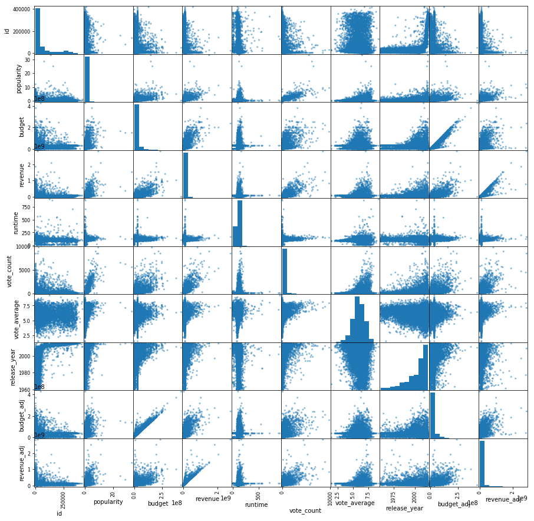

```python
pd.plotting.scatter_matrix(movies, figsize = (15,15));
```

**Observations**

### 1. What are the number of movies released each year?

```python
# grouping number of movies by year
movies_released = movies.groupby(['release_year'])['id'].count().reset_index()
movies_released.head()
```

|  | release_year | id |
| --- | --- | --- |
| 0 | 1960 | 32 |
| 1 | 1961 | 31 |
| 2 | 1962 | 32 |
| 3 | 1963 | 34 |
| 4 | 1964 | 42 |

```
Text(0,0.5,'Number of Movies')
```

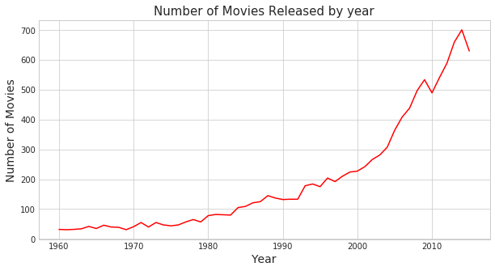

```python
# visualize the above result

#set the sheet style
sns.set_style('whitegrid')

x = movies_released.release_year
y = movies_released.id

plt.figure(figsize=(10,5))
plt.plot(x, y, color='red')
plt.title('Number of Movies Released by year', fontsize = 15)
plt.xlabel('Year', fontsize=14)
plt.ylabel('Number of Movies', fontsize=14)
```

### 2. What is the relationship between movie budget and revenue?

```python
movies.columns
```

```
Index(['id', 'popularity', 'budget', 'revenue', 'original_title', 'runtime',
       'genres', 'release_date', 'vote_count', 'vote_average', 'release_year',
       'budget_adj', 'revenue_adj'],
      dtype='object')
```

```
0.524506836494574
```

```
Text(0,0.5,'Revenue')
```

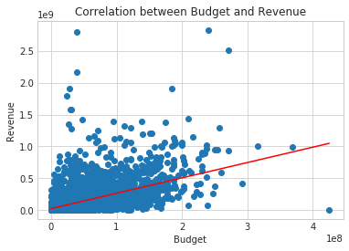

```python
x = movies["budget_adj"]
y = movies["revenue_adj"]
correlation_movies = x.corr(y)
print(correlation_movies)

# add title to plot
plt.title('Correlation between Budget and Revenue')
# plotting the data
plt.scatter(x,y)

# This will fit the best line into the graph
plt.plot(np.unique(x), np.poly1d(np.polyfit(x, y, 1))
         (np.unique(x)), color='red')

# labelling axes
plt.xlabel('Budget')
plt.ylabel('Revenue')
```

**The above output shows a positive relation between the Budget and Revenue.**

```python
budgets = movies.groupby('release_year').mean()['budget_adj']
revenues = movies.groupby('release_year').mean()['revenue_adj']
```

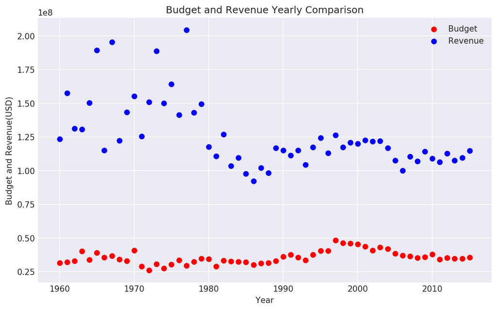

```python
# line graph
sns.set_style('darkgrid')

x1 = budgets.index
y1 = budgets
x2 = revenues.index
y2 = revenues

plt.figure(figsize=(10,6), dpi = 150)

plt.scatter(x1, y1, color='red', label = 'Budget')
plt.scatter(x2, y2, color='blue', label = 'Revenue')

plt.title('Budget and Revenue Yearly Comparison')

plt.xlabel('Year')
plt.ylabel('Budget and Revenue(USD)')

plt.legend(loc = 'upper right')

plt.show();
```

**Observarions**

- The graph above shows the revenue remaining higher than the budget as the years go by, this further shows that they have a positively correlated relationship.

### 3. What is the most profitable movie?

- I would calculate the profit first by checking the difference between the budget and revenue and make the profit appear in a new column

```python
movies.head()
```

|  | id | popularity | budget | revenue | original_title | runtime | genres | release_date | vote_count | vote_average | release_year | budget_adj | revenue_adj |
| --- | --- | --- | --- | --- | --- | --- | --- | --- | --- | --- | --- | --- | --- |
| 0 | 135397 | 32.985763 | 150000000.0 | 1.513529e+09 | Jurassic World | 124.0 | Action\|Adventure\|Science Fiction\|Thriller | 2015-06-09 | 5562 | 6.5 | 2015 | 1.379999e+08 | 1.392446e+09 |
| 1 | 76341 | 28.419936 | 150000000.0 | 3.784364e+08 | Mad Max: Fury Road | 120.0 | Action\|Adventure\|Science Fiction\|Thriller | 2015-05-13 | 6185 | 7.1 | 2015 | 1.379999e+08 | 3.481613e+08 |
| 2 | 262500 | 13.112507 | 110000000.0 | 2.952382e+08 | Insurgent | 119.0 | Adventure\|Science Fiction\|Thriller | 2015-03-18 | 2480 | 6.3 | 2015 | 1.012000e+08 | 2.716190e+08 |
| 3 | 140607 | 11.173104 | 200000000.0 | 2.068178e+09 | Star Wars: The Force Awakens | 136.0 | Action\|Adventure\|Science Fiction\|Fantasy | 2015-12-15 | 5292 | 7.5 | 2015 | 1.839999e+08 | 1.902723e+09 |
| 4 | 168259 | 9.335014 | 190000000.0 | 1.506249e+09 | Furious 7 | 137.0 | Action\|Crime\|Thriller | 2015-04-01 | 2947 | 7.3 | 2015 | 1.747999e+08 | 1.385749e+09 |

```python
movies['Profit'] = movies['revenue_adj'] - movies['budget_adj']
```

- Show the dataframe to see the new column (Profit)

```python
movies.head()
```

|  | id | popularity | budget | revenue | original_title | runtime | genres | release_date | vote_count | vote_average | release_year | budget_adj | revenue_adj | Profit |
| --- | --- | --- | --- | --- | --- | --- | --- | --- | --- | --- | --- | --- | --- | --- |
| 0 | 135397 | 32.985763 | 150000000.0 | 1.513529e+09 | Jurassic World | 124.0 | Action\|Adventure\|Science Fiction\|Thriller | 2015-06-09 | 5562 | 6.5 | 2015 | 1.379999e+08 | 1.392446e+09 | 1.254446e+09 |
| 1 | 76341 | 28.419936 | 150000000.0 | 3.784364e+08 | Mad Max: Fury Road | 120.0 | Action\|Adventure\|Science Fiction\|Thriller | 2015-05-13 | 6185 | 7.1 | 2015 | 1.379999e+08 | 3.481613e+08 | 2.101614e+08 |
| 2 | 262500 | 13.112507 | 110000000.0 | 2.952382e+08 | Insurgent | 119.0 | Adventure\|Science Fiction\|Thriller | 2015-03-18 | 2480 | 6.3 | 2015 | 1.012000e+08 | 2.716190e+08 | 1.704191e+08 |
| 3 | 140607 | 11.173104 | 200000000.0 | 2.068178e+09 | Star Wars: The Force Awakens | 136.0 | Action\|Adventure\|Science Fiction\|Fantasy | 2015-12-15 | 5292 | 7.5 | 2015 | 1.839999e+08 | 1.902723e+09 | 1.718723e+09 |
| 4 | 168259 | 9.335014 | 190000000.0 | 1.506249e+09 | Furious 7 | 137.0 | Action\|Crime\|Thriller | 2015-04-01 | 2947 | 7.3 | 2015 | 1.747999e+08 | 1.385749e+09 | 1.210949e+09 |

```python
highest_profit_movie = movies.groupby(['original_title'])['Profit'].sum().reset_index()
highest_profit_movie = highest_profit_movie.sort_values(by='Profit', ascending=False)
highest_profit_movie.head()
```

|  | original_title | Profit |
| --- | --- | --- |
| 7368 | Star Wars | 2.750137e+09 |
| 818 | Avatar | 2.586237e+09 |
| 9718 | Titanic | 2.331742e+09 |
| 8279 | The Exorcist | 2.128036e+09 |
| 4287 | Jaws | 1.878643e+09 |

### 4. What is the least profitable movie?

```python
highest_profit_movie.tail()
```

|  | original_title | Profit |
| --- | --- | --- |
| 2083 | Cutthroat Island | -1.137371e+08 |
| 1485 | Brother Bear | -1.185350e+08 |
| 7757 | The 13th Warrior | -1.286813e+08 |
| 8780 | The Lone Ranger | -1.551102e+08 |
| 9530 | The Warrior's Way | -4.139124e+08 |

**Observation**

- **Star Wars** is the movie with the **Highest Profit.** Showing that it is the most profitable in the dataset.
- **The Warrior's Way** is the movie with the **Lowest Profit** (which actually made a great loss.

## Conclusions

> **One**: There has been a great significant increase in the number of movies released each year since 1960 up to 2015, judging from the increased seen in the visualization.

> **Two**: The revenue of movies consistenty remained above the budget each year.

> **Three**: Budget and Revenue have a positively correlated relationship. Through the succeeding years, the revenue was higher that the budget of movies.

> **Four**: **Star Wars** made the most profit as the movie released in the dataset through year 1960 - 2015.

> **Five**: The Warrior's Way made the least profit, in other words, it recorded the lowest profit in the entire dataset.

## Limitations

> **One**: The number of zeros in the columns I needed for my data analysis was much and quite an issue, so, I decided to keep all the zero values instead of dropping them from the dataset.So, I replaced the zero values in each column with NaN (not a number) and replace with mean values.

> **Two**: I wasn't aure how exactly the vote_average and vote_count are calculated so I couldn't use them for my analysis, such as calculating movie rating over a time period (month/year).

```python
from subprocess import call
call(['python', '-m', 'nbconvert', 'Investigate_a_Dataset.ipynb'])
```

```
0
```